# ANALISIS DATOS INDICE MUNICIPIO DIGITAL 2025

Author

Cristóbal Cabezas - Línea Política Nuleo Milenio NUDOS

```r
setwd(here::here())
source("scripts/2025/b1-proc-data.R")
```

```
To access larger datasets in this package, install the spDataLarge
package with: `install.packages('spDataLarge',
repos='https://nowosad.github.io/drat/', type='source')`
```

# 1. Introducción

El presente reporte realiza, a través de distintas tablas y figuras, un análisis de las diferencias en los valores para del Índice de Municipio Digital (MD) para el período 2024-2025. Este índice, junto a los de Conectividad Hogar (CH) y Educación Digital (ED), conforman el Índice de Digitalización Comunal (IDC) desarrollado por el Núcleo Milenio NUDOS.

# 2. Estado de avance: recopilación de información

Tabla 1: Avance en recopilación de información subdimención MD para comunas 2025, ordenadas de norte a sur

| Región | Total de comunas | Comunas cubiertas | Porcentaje |
| --- | --- | --- | --- |
| Arica y Parinacota | 4 | 4 | 100% |
| Tarapacá | 7 | 7 | 100% |
| Antofagasta | 9 | 9 | 100% |
| Atacama | 9 | 9 | 100% |
| Coquimbo | 15 | 15 | 100% |
| Valparaíso | 38 | 38 | 100% |
| Metropolitana | 52 | 51 | 98,07% |
| O’Higgins | 33 | 31 | 93,93% |
| Maule | 30 | 30 | 100% |
| Ñuble | 21 | 21 | 100% |
| Biobío | 33 | 33 | 100% |
| Araucanía | 32 | 31 | 96,88% |
| Los Ríos | 12 | 12 | 100% |
| Los Lagos | 30 | 29 | 96,97% |
| Aysén | 10 | 10 | 100% |
| Magallanes | 10 | 10 | 100% |
| TOTAL | 345 | 340 | 98,55% |

# 3. Grado de implementación: dimensiones del índice de Municipio Digital

El índice de Municipio Digital se compone de dos dimensiones, Pagos, Trámites y Servicios en Línea (PTSL), e Información y Transparencia Sustantiva (ITS). La primera se compone de 14 variables binarias, donde su grado de implementación se relaciona a la posibilidad (1) o no (0) de realizar como ciudadano una serie de trámites en el sitio web del respectivo municipio: `pago_circulacion`, `pago_multas`, `pago_patentes`, `pago_aseo`, `pago_varios`, `clave_unica`, `dom_dig`, `"tvecino"`, `omil_dig`, `trans_dig`, `patentes_dig`, `oirs_dig`, `ornato_dig` y `app`.

Por otra parte, la segunda dimensión se compone de 20 variables relacionadas a la posibilidad de acceder a distintos tipos de información administrativa desde el sitio web del municipio: `plan_regulador`, `concursos_publicos`, `actas_concejo`, `sesiones_concejo`, `ordenan`, `cod_etica`, `pladeco`, `sol_audiencia`, `trans_activa`, `acceso_info`, `datos_ab`, `org_comunitarias`, `gestion_publica`, `lobby`, `compras`, `redes`, `sub_becas`, `denuncias`, `org_municipal` y `noticias`.

En el sentido de lo anterior, se realiza a continuación un análisis comparativo entre el grado de implementación de las variables de cada dimensión entre 2024 y 2025.

## 3.1. Dimensión Pagos, Trámites y Servicios en Línea (PTSL)

Gráfico 1: Grado de implementación variables de dimensión PSTL: 2024 vs 2025

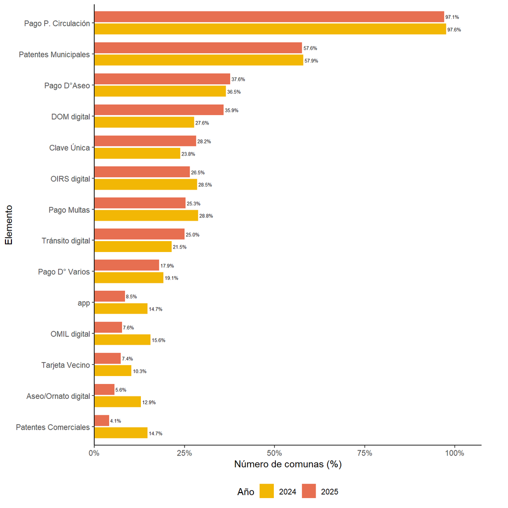

## 3.2. Dimensión Información y Transparencia Sustantiva

Se destaca también la consistencia para ambos años en elementos con bajo grado de cumplimiento, como Solicitudes de Audiencia (5,3% y 5,9%), Códigos de Ética (5,6% y 5,9%) y Datos Abiertos (6,8 y 5%).

Gráfico 2: Grado de implementación cumplimiento dimensión ITS: 2024 vs 2025

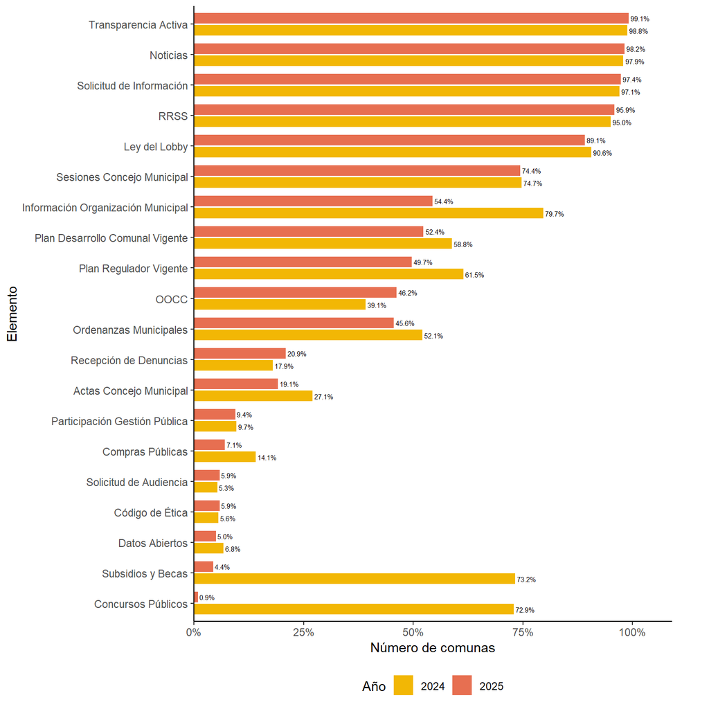

# 4. Distribución y comparación de puntajes

## 4.0 Nivel anual

Estadísticos descriptivos para cada año

| year | n | mean | sd | median | IQR | min | max |
| --- | --- | --- | --- | --- | --- | --- | --- |
| 2024 | 340 | 0.5 | 0.099 | 0.485 | 0.138 | 0.191 | 0.788 |
| 2025 | 340 | 0.5 | 0.100 | 0.479 | 0.145 | 0.291 | 0.754 |

- Mediana baja de 0.485 → 0.479 (−0.006). Deslizamiento leve a la baja del municipio mediano
- Dispersión central: el IQR sube 0.138 → 0.145 (+0.007 ≈ +0.07 SD). Aumento leve de la heterogeneidad entre el 50% central de comunas en 2025
- Mínimo: 0.191 → 0.291 (+0.100). Los peores mejoran
- Máximo: 0.788 → 0.754 (−0.034). Los mejores retroceden levemente
- Rango total cae ~22% (0.597 → 0.463): menor brecha extrema, con convergencia desde los extremos.

Gráfico 3: Correlación puntajes MD de año 2024 a 2025

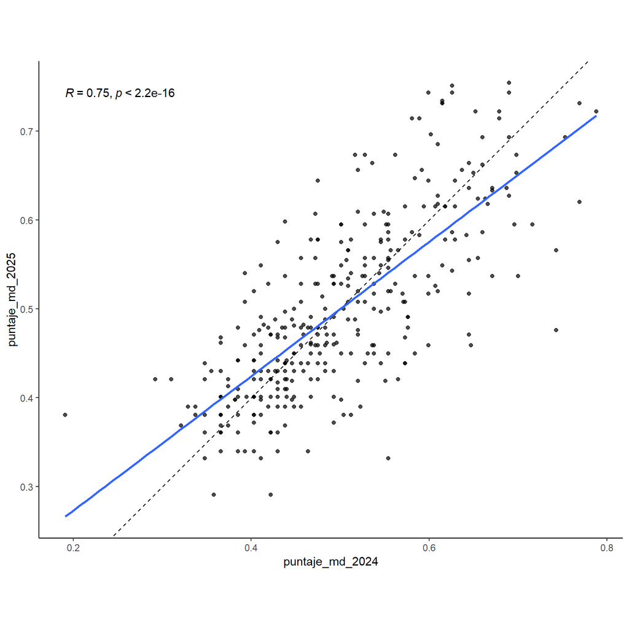

```
Call:
lm(formula = delta ~ puntaje_md_2024, data = corr)

Residuals:
      Min        1Q    Median        3Q       Max
-0.208641 -0.039992 -0.003298  0.040030  0.168378

Coefficients:
                Estimate Std. Error t value Pr(>|t|)
(Intercept)      0.12229    0.01849   6.613 1.47e-10 ***
puntaje_md_2024 -0.24485    0.03627  -6.751 6.41e-11 ***
---
Signif. codes:  0 '***' 0.001 '**' 0.01 '*' 0.05 '.' 0.1 ' ' 1

Residual standard error: 0.06631 on 338 degrees of freedom
Multiple R-squared:  0.1188,    Adjusted R-squared:  0.1162
F-statistic: 45.58 on 1 and 338 DF,  p-value: 6.411e-11
```

- Pendiente: −0.2449 (SE 0.0363, p ≈ 6.4e−11).
  - Cada +0.10 en el puntaje 2024 se asocia con un −0.024 en el cambio (2025−2024).
  - Intercepto: 0.1223 (p ≈ 1.5e−10), lo que predice cambio positivo cuando 2024 es muy bajo.
  - Punto de cruce (donde Δ=0) bajo ~0.499: las comunas suben en promedio; sobre ~0.499 bajan levemente.

## 4.1. Nivel Regional

Tabla 4: Estadísticos descriptivos a agregados a nivel de región

Cambios 2025–2024 por región (medianas, dispersión y prueba pareada)

| region | n_comunas | med_2024 | med_2025 | d_med | iqr_2024 | iqr_2025 | d_iqr | mean_delta | prop_suben | p_wilcoxon | p_adj |
| --- | --- | --- | --- | --- | --- | --- | --- | --- | --- | --- | --- |
| TARAPACA | 7 | 0.414 | 0.482 | 0.068 | 0.143 | 0.150 | 0.007 | 0.016 | 0.571 | 0.447 | 0.596 |
| LOS RIOS | 12 | 0.484 | 0.536 | 0.052 | 0.066 | 0.101 | 0.035 | 0.029 | 0.833 | 0.005 | 0.029 |
| MAULE | 30 | 0.474 | 0.520 | 0.047 | 0.107 | 0.097 | -0.010 | 0.044 | 0.800 | 0.001 | 0.004 |
| AYSEN | 10 | 0.403 | 0.449 | 0.046 | 0.063 | 0.071 | 0.008 | 0.028 | 0.700 | 0.066 | 0.147 |
| BIOBIO | 33 | 0.467 | 0.508 | 0.041 | 0.116 | 0.144 | 0.028 | 0.033 | 0.727 | 0.009 | 0.034 |
| METROPOLITANA | 51 | 0.570 | 0.607 | 0.037 | 0.113 | 0.147 | 0.035 | 0.022 | 0.647 | 0.028 | 0.090 |
| ARICA Y PARINACOTA | 4 | 0.447 | 0.459 | 0.012 | 0.112 | 0.095 | -0.018 | 0.011 | 0.750 | 0.201 | 0.322 |
| ATACAMA | 9 | 0.385 | 0.390 | 0.005 | 0.117 | 0.090 | -0.027 | -0.022 | 0.444 | 0.722 | 0.825 |
| LOS LAGOS | 29 | 0.456 | 0.459 | 0.003 | 0.106 | 0.104 | -0.002 | 0.001 | 0.379 | 0.658 | 0.809 |
| NUBLE | 21 | 0.459 | 0.459 | 0.000 | 0.071 | 0.055 | -0.016 | 0.002 | 0.429 | 0.945 | 0.945 |
| ARAUCANIA | 31 | 0.475 | 0.471 | -0.004 | 0.126 | 0.097 | -0.029 | -0.014 | 0.290 | 0.051 | 0.136 |
| MAGALLANES | 10 | 0.448 | 0.440 | -0.008 | 0.107 | 0.071 | -0.037 | -0.012 | 0.400 | 0.359 | 0.522 |
| ANTOFAGASTA | 9 | 0.549 | 0.526 | -0.023 | 0.167 | 0.139 | -0.028 | 0.005 | 0.556 | 0.906 | 0.945 |
| OHIGGINS | 31 | 0.464 | 0.439 | -0.025 | 0.129 | 0.106 | -0.023 | -0.023 | 0.484 | 0.167 | 0.297 |
| COQUIMBO | 15 | 0.504 | 0.450 | -0.054 | 0.126 | 0.099 | -0.028 | -0.040 | 0.267 | 0.074 | 0.147 |
| VALPARAISO | 38 | 0.526 | 0.465 | -0.061 | 0.177 | 0.115 | -0.062 | -0.064 | 0.184 | 0.000 | 0.001 |

Gráfico 4: Boxplot de puntajes MD agregados a nivel de región

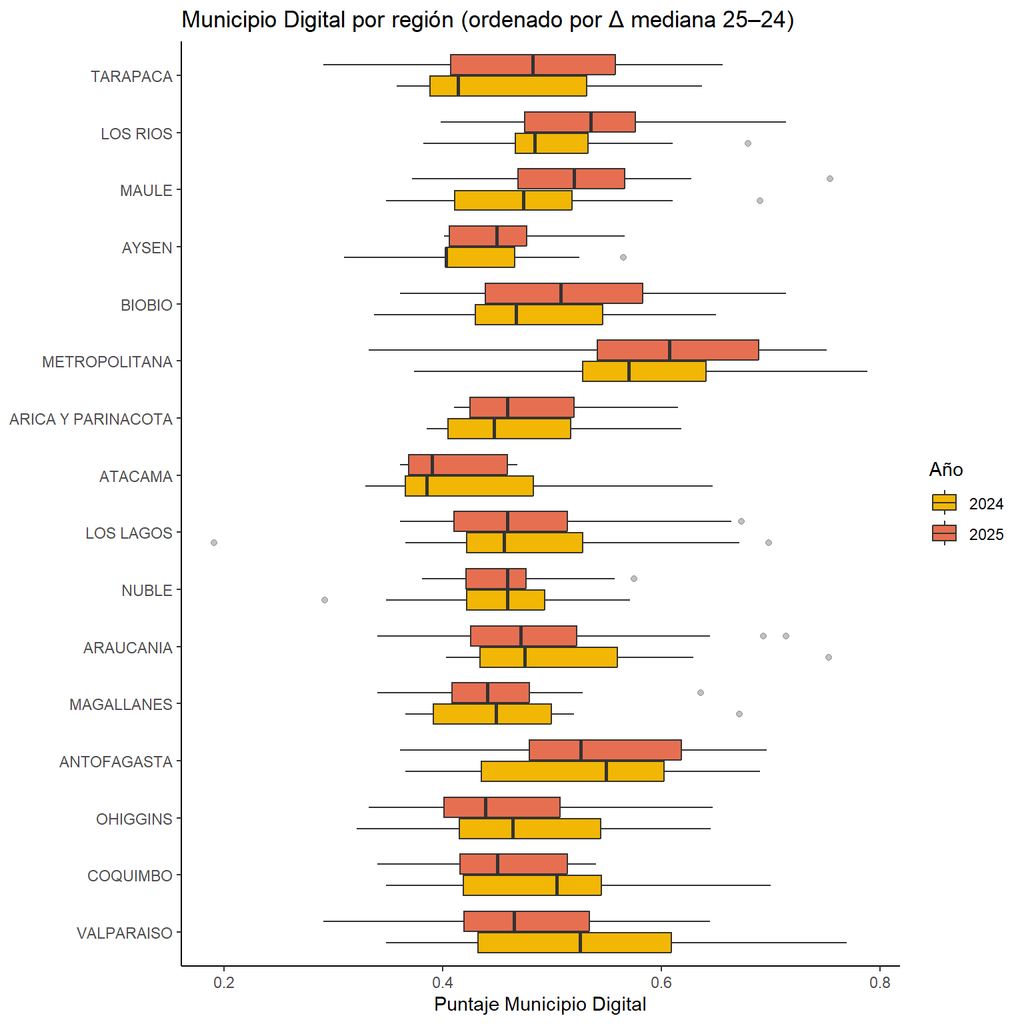

- Regiones que mejoran de forma clara (mediana ↑ y significancia tras método de ajuste por comparaciones múltiples)
  - Los Ríos (+0.052; *p* adj = 0.029)
  - Maule (+0.047; *p* adj = 0.004)
  - Biobío (+0.041; *p* adj = 0.034).
  - En las tres, el boxplot naranja queda por encima del amarillo y el % de comunas que suben es alto (83%, 80% y 73% respectivamente)
- Mejora moderada (tendencia, pero sin significancia tras ajuste ajuste por comparaciones múltiples):
  - Metropolitana (+0.037; *p* adj = 0.090)
  - Aysén (+0.046; 0.147), Tarapacá (+0.068; 0.596).
  - Ojo con Tarapacá 7 y Aysén 10) y su diferencia de n respecto a RM
- Estables / cambios mínimos:
  - Arica y Parinacota (+0.012),
  - Atacama (+0.005),
  - Los Lagos (+0.003),
  - Ñuble (0.000).
  - Boxplots casi solapados.
- Retrocesos:
  - Valparaíso(−0.061; *p* adj = 0.001)
  - Coquimbo también baja (−0.054; 0.147).
- Heterogeneidad intra región (IQR)
  - Más dispersión en 2025 (aumento brecha interna):
    - Metropolitana (+0.035)
    - Biobío (+0.028)
    - Los Ríos (+0.035)
    - tarapacá (+0.007)
    - Aysén (+0.008)
  - Menos dispersión (convergencia):
    - Valparaíso (−0.062, convergencia hacia abajo)
    - Coquimbo (−0.027),
    - Araucanía (−0.029)
    - Magallanes (−0.037),
    - Atacama (−0.027).

Gráfico 5: Cruce entre delta mediana vs cambios en delta IQR, por región

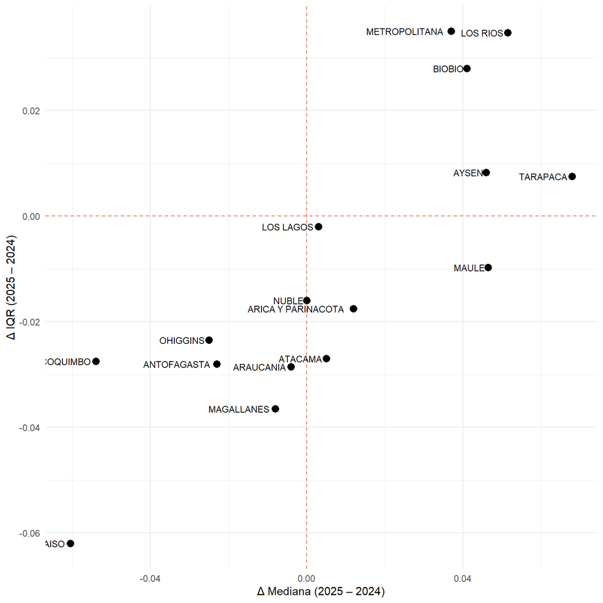

El gráfico articula en el eje X la variación de la mediana regional del puntaje de “Municipio Digital” (2025 – 2024) y en el eje Y la variación de su IQR (2025 – 2024). De ese cruce surgen cuatro cuadrantes conceptuales:

- Mejora con mayor heterogeneidad (Δ mediana > 0; Δ IQR > 0): RM, Biobío, Los Ríos, Aysén, Tarapacá
- Mejora con convergencia (Δ mediana > 0; Δ IQR < 0): Arica y Parinacota, Maule, Atacama
- Retroceso con convergencia (Δ mediana < 0; Δ IQR < 0): Coquimbo, O’Higgins, Antofagasta, Magallanes, Araucanía, Valparaíso
- Ninguna región presenta el cuadrante de retroceso con mayor heterogeneidad (Δ mediana < 0; Δ IQR > 0)
- Casos particulares: Los Lagos (muy cerca del cruce en 0 de ambos ejes) y Ñuble (Sólo disminuyó IQR)

## 4.2. Nivel Comunal

### 4.2.1. Comunas ordenadas de menor a mayor puntaje 2024-2025

Gráfico 6: Puntaje subdimensión MD por comuna (2024–2025)

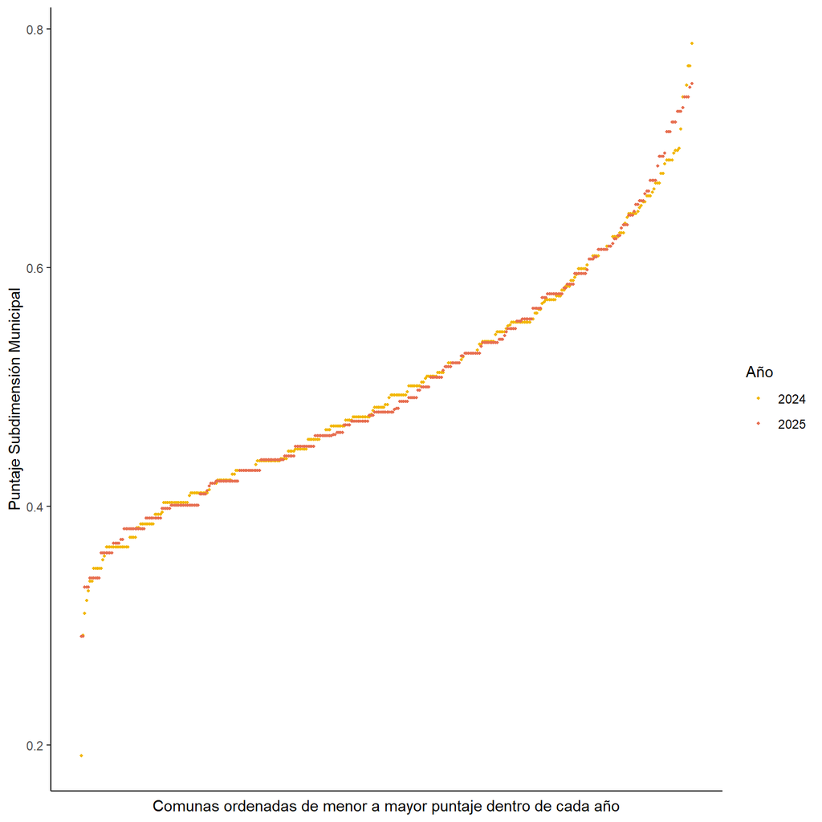

### 4.2.2. N° de comunas por tramo

Tabla 5: Valores de las tramos de MD establecidos para 2024

| Tramo | Valores |
| --- | --- |
| Alto | 0,565 a 0,788 |
| Medio Alto | 0,491 a 0,562 |
| Medio Bajo | 0,430 a 0,485 |
| Bajo | 0,191 a 0,427 |

Tabla 6: Número de Comunas según tramos de Municipio Digital 2024, para datos de 2024 y 2025

| Categoría del Ranking | N° Comunas 2024 (n = 345) | N° Comunas 2025 (n = 340) | Diferencia |
| --- | --- | --- | --- |
| Alto | 87 | 89 | +2 |
| Medio-Alto | 85 | 74 | -11 |
| Medio-bajo | 86 | 89 | +3 |
| Bajo | 87 | 88 | +1 |

### 4.2.3. Top 10 comunas con mayor puntaje en 2025

Tabla 7: Diez comunas con los mayores valores de Municipio Digital 2025.

| Posición 2025 | Comuna 2025 | Puntaje 2025 | Cambio en posición con respecto a 2024 |
| --- | --- | --- | --- |
| 1 | San Clemente | 0,754 | +14 posiciones |
| 2 | Maipú | 0,751 | +40 posiciones |
| 3 | Ñuñoa | 0,743 | +9 posiciones |
| 4 | Pudahuel | 0,743 | +39 posiciones |
| 5 | Quinta Normal | 0,743 | +55 posiciones |
| 6 | La Florida | 0,734 | +44 posiciones |
| 7 | La Reina | 0,731 | -5 posiciones |
| 8 | Lo Barnechea | 0.731 | +43 posiciones |
| 9 | Providencia | 0.731 | +43 posiciones |
| 10 | Las Condes | 0,722 | -9 Posiciones |

### 4.2.4. Top 10 comunas con menor puntaje

| Posición | Comuna 2025 | Puntaje 2025 | Cambio en posición con respecto a 2024 |
| --- | --- | --- | --- |
| 340 | Santa María | 0.291 | -79 posiciones |
| 339 | Camiña | 0.291 | -120 posiciones |
| 338 | Estación Central | 0.332 | -245 posiciones |
| 337 | Pumanque | 0.332 | -5 posiciones |
| 336 | Isla de Pascua | 0.332 | -60 posiciones |
| 335 | Primavera | 0.340 | -17 posiciones |
| 334 | Río verde | 0.340 | -34 posiciones |
| 333 | Lumaco | 0.340 | -41 posiciones |
| 332 | Codegua | 0.340 | -129 posiciones |
| 331 | Rinconada | 0.340 | -84 posiciones |

### 4.2.5. Top 10 de comunas con mayor variación de puntaje MD

Gráfico 7: Comunas con mayor variación en puntaje MD

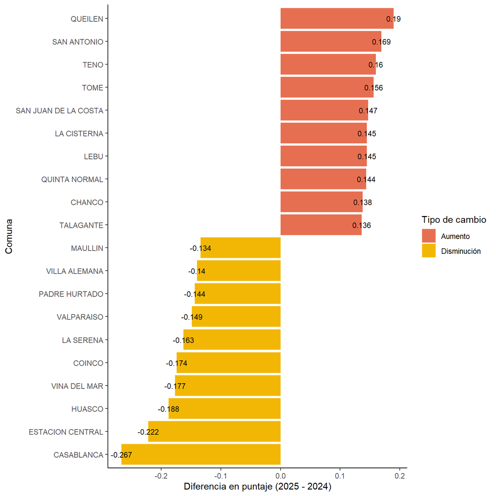

# 5. Anexo: Visualización por regiones para puntajes MD 2025.

## 5.1. Arica y Parinacota

Gráfico 8: puntajes MD 2025 en la Región de Arica

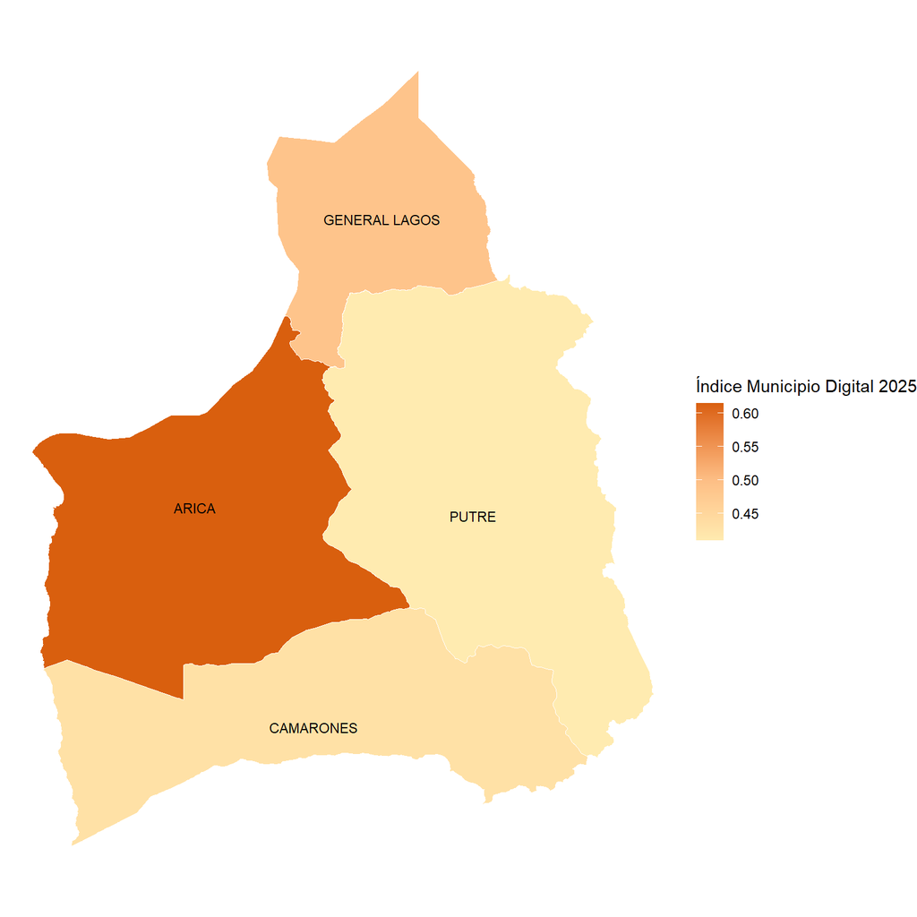

## 5.2. Tarapacá

Gráfico 9: Puntajes MD 2025 en la Región de Tarapacá

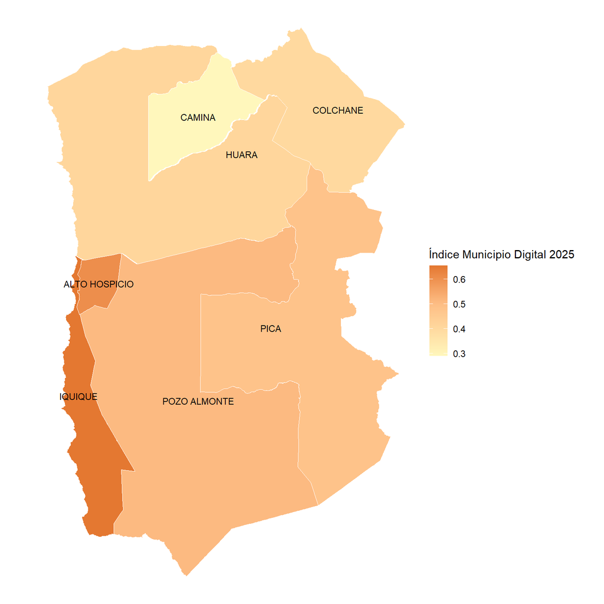

## 5.3. Antofagasta

Gráfico 10: Puntajes MD 2025 en la Región de Antofagasta

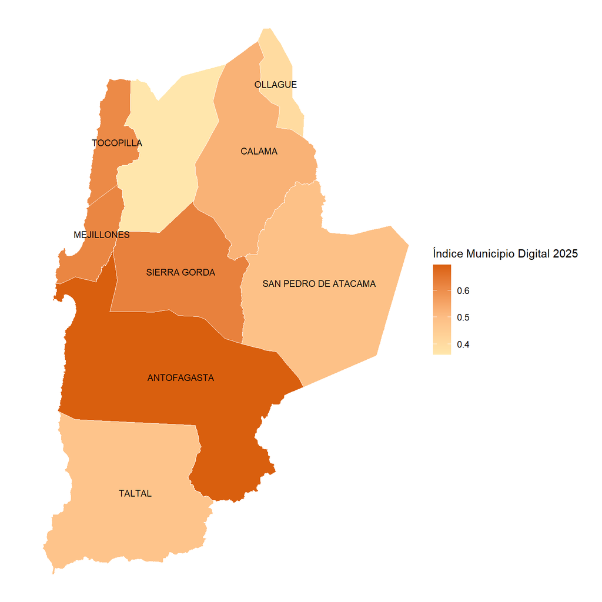

## 5.4. Atacama

Gráfico 11: Puntaje MD 2025 en la Región de Atacama

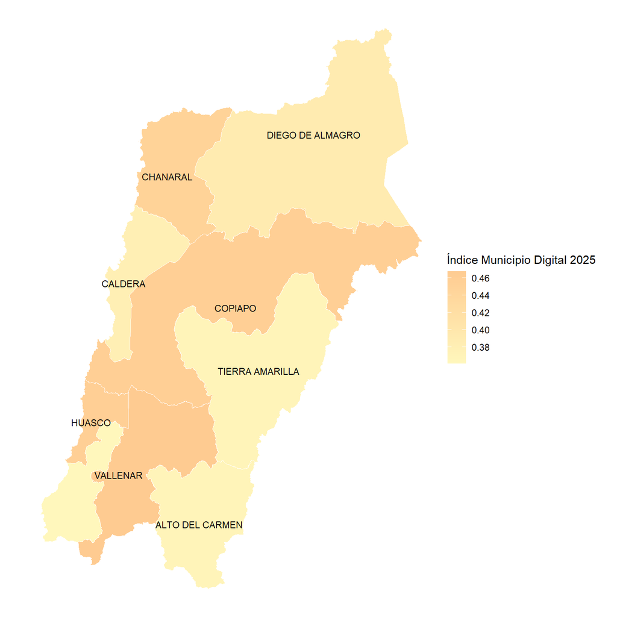

## 5.5. Coquimbo

Gráfico 12: Puntaje MD 2025 en la Región de Coquimbo

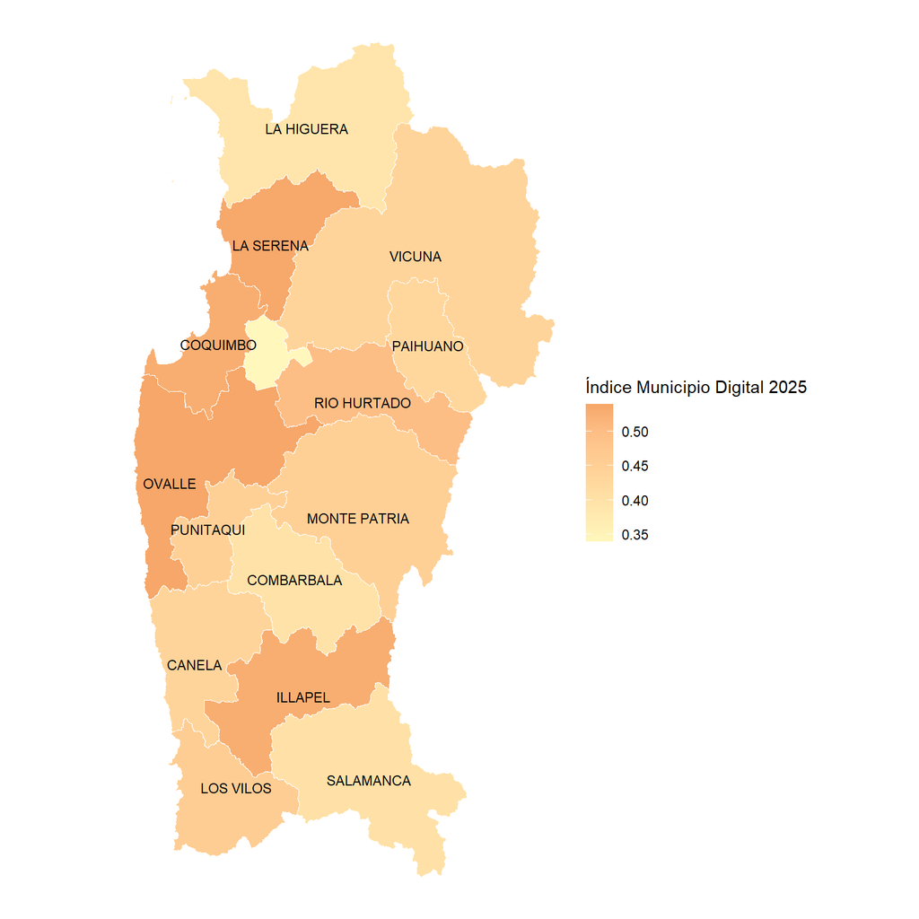

## 5.6. Valparaíso

Gráfico 13: Puntaje MD 2025 en la Región de Valparaíso

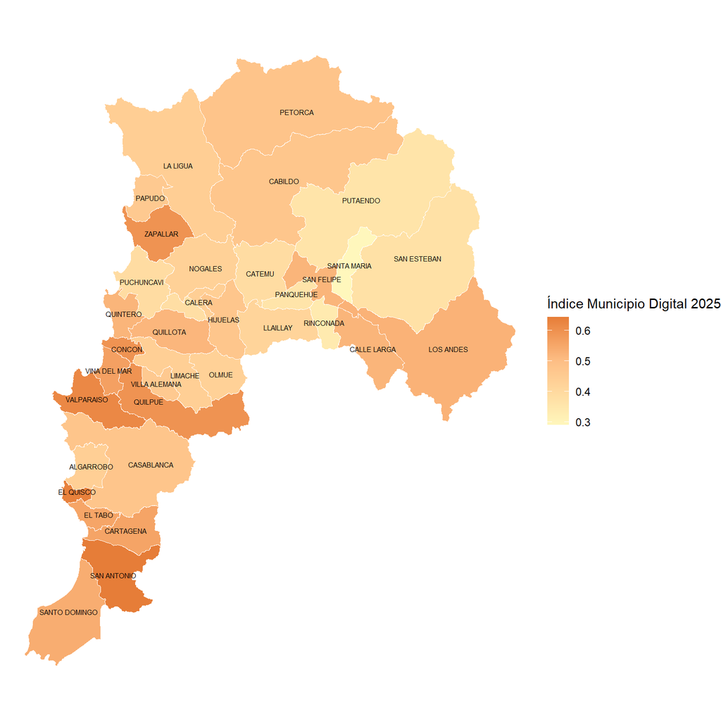

Nota: se excluyen Isla de Pascua y Juan Fernández por dificultades para visualización con ggplot2.

## 5.7. Metropolitana

Gráfico 14: Puntaje MD 2025 en la Región Metropolitana

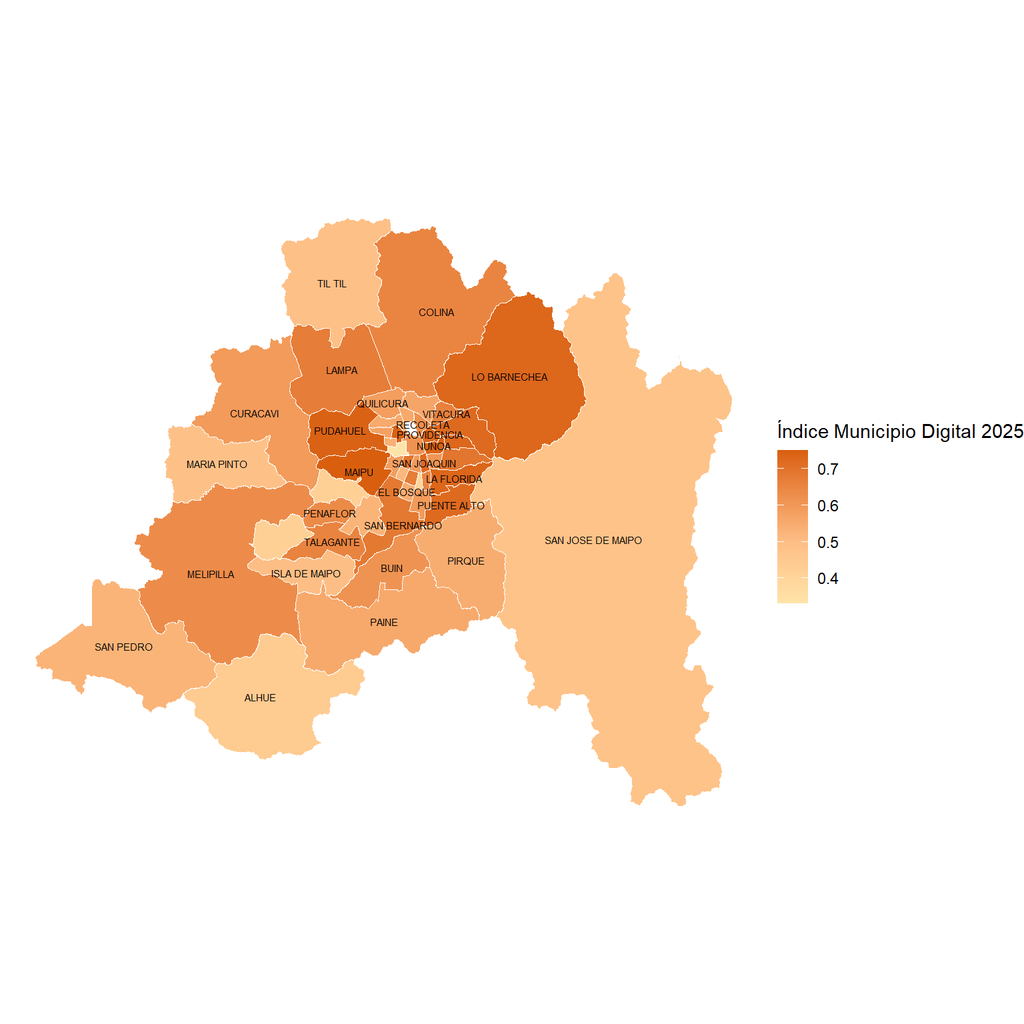

## 5.8. O’Higgins

Gráfico 15: Puntaje MD 2025 en la Región de O’Higgins

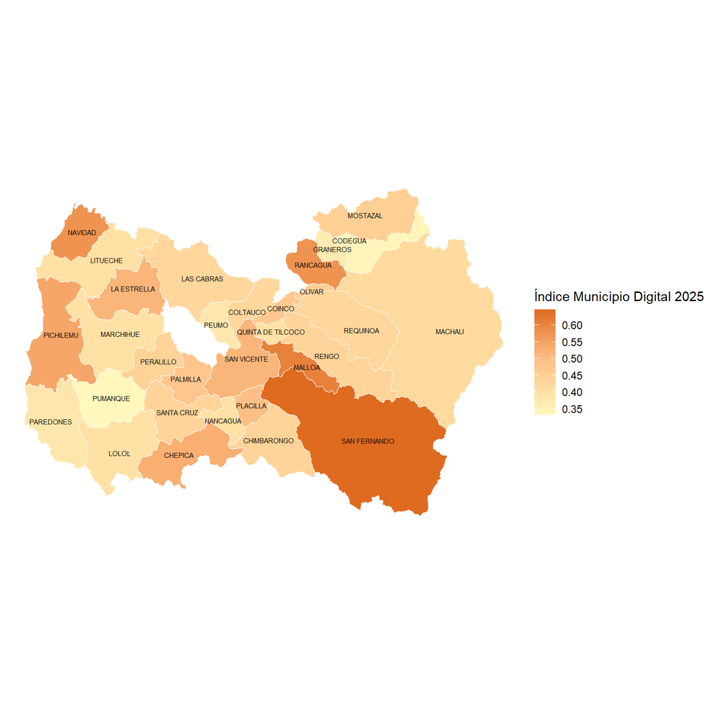

## 5.9. Maule

Gráfico 16: Puntaje MD 2025 en la Región de Maule

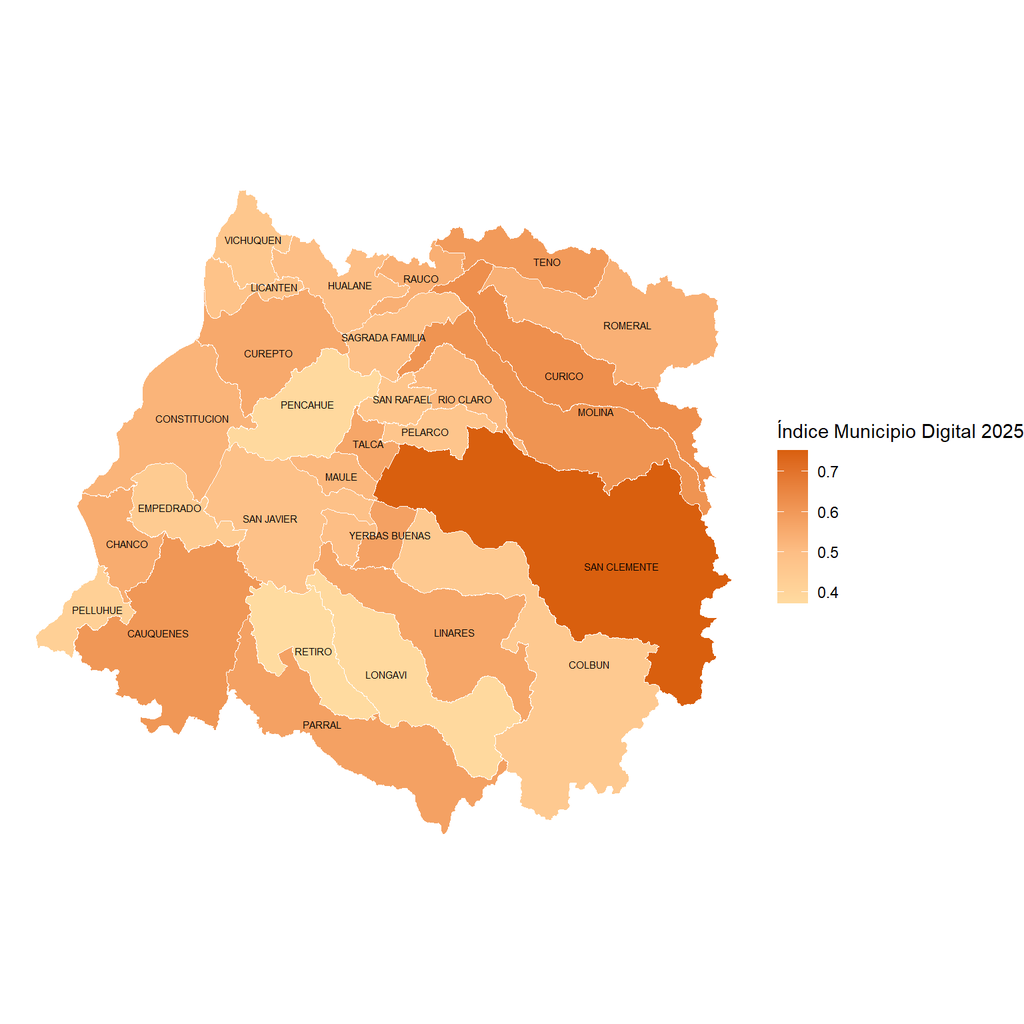

## 5.10. Ñuble

Gráfico 17: Puntaje MD 2025 en la Región de Ñuble

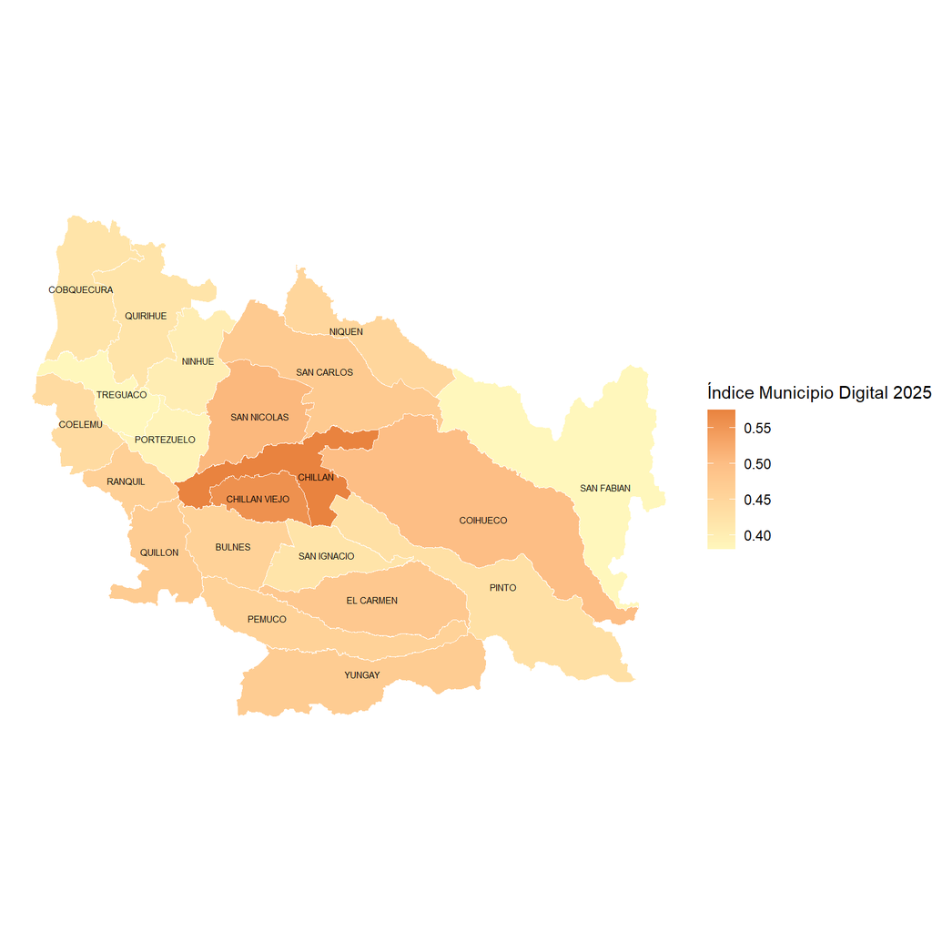

## 5.11. Biobío

Gráfico 18: Puntaje MD 2025 en la Región de Biobío

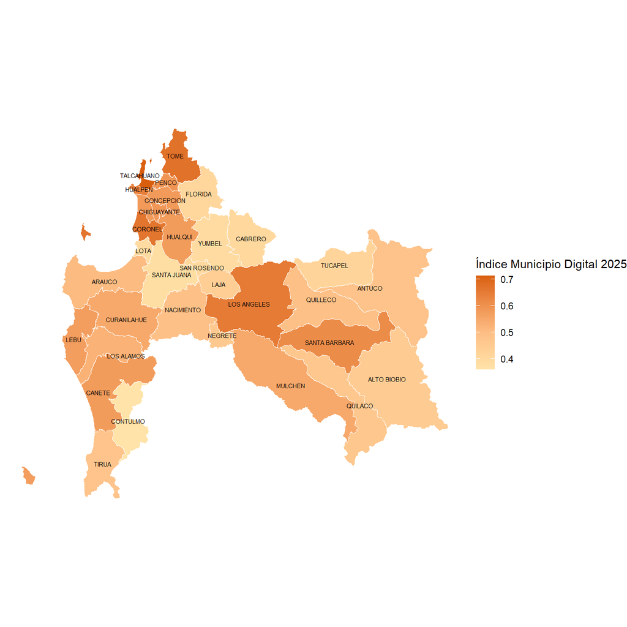

## 5.12. Araucanía

Gráfico 19: Puntaje MD 2025 en la Región de La Araucanía

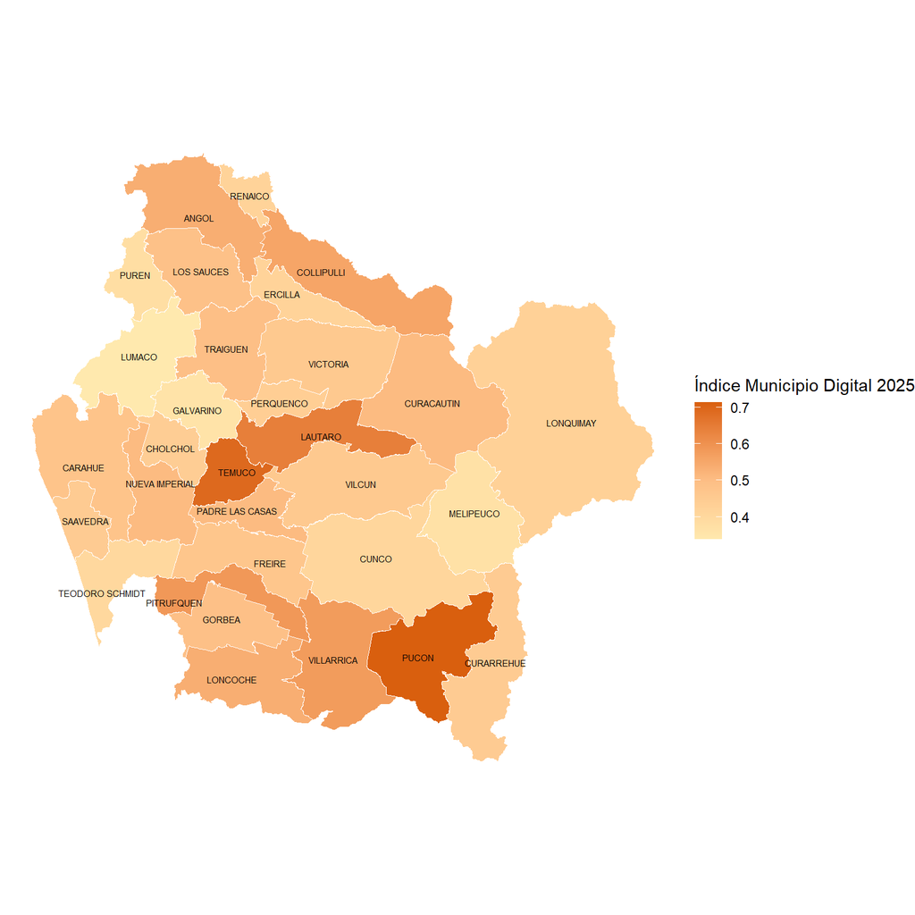

## 5.13. Los Ríos

Gráfico 20: Puntaje MD 2025 en la Región de Los Ríos

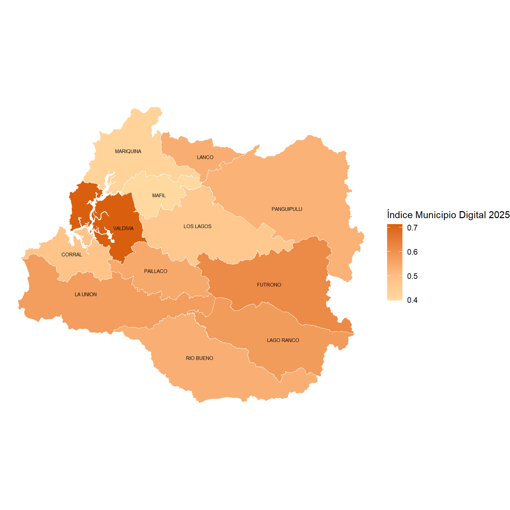

## 5.14. Los Lagos

Gráfico 21: Puntaje MD 2025 en la Región de Los Lagos

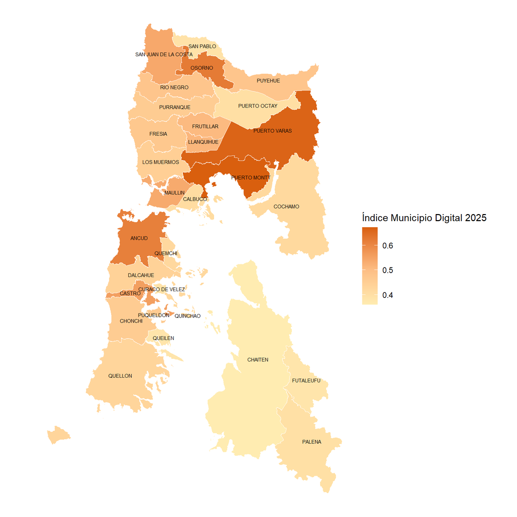

## 5.15. Aysén

Gráfico 22: Puntaje MD 2025 en la Región de Aysén

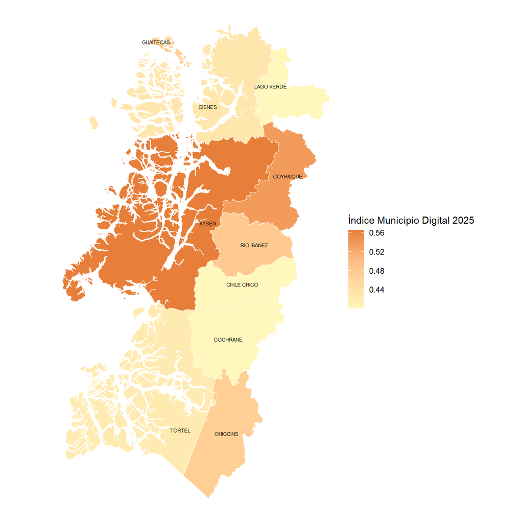

## 5.16 Magallanes

Gráfico 23: Puntaje MD 2025 en la Región de Magallanes

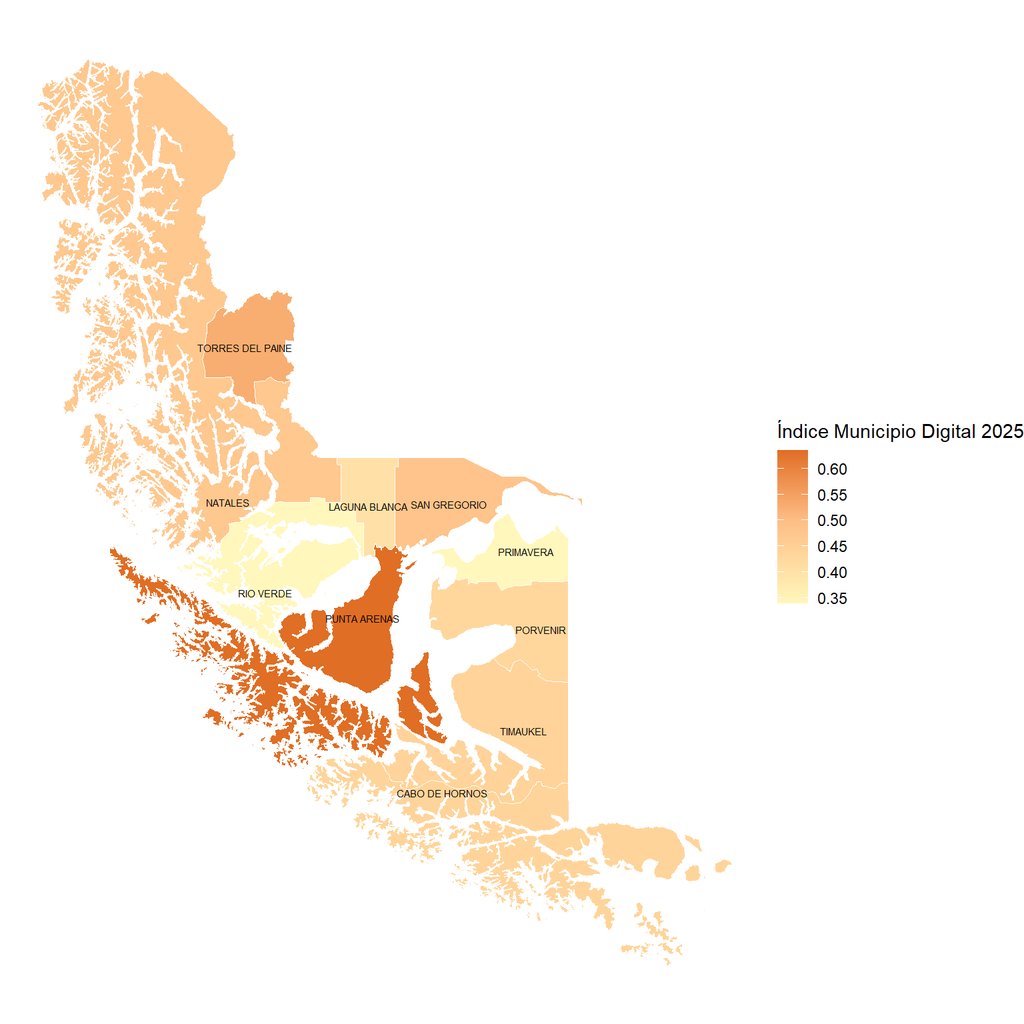